# ICE Arrests: Tennessee After January 20, 2025

Detention itineraries, transfer flows, and removal outcomes

Published

November 18, 2026

This report traces ICE arrests made in **Tennessee** on or after **January 20, 2025** through the full detention and removal pipeline, using individual-level FOIA data from the [Deportation Data Project](https://deportationdata.org).

**14,656** arrests · **14,495** distinct individuals · **14,806** detention stays · **84.2%** ultimately removed

## Overview

### Monthly arrest volume

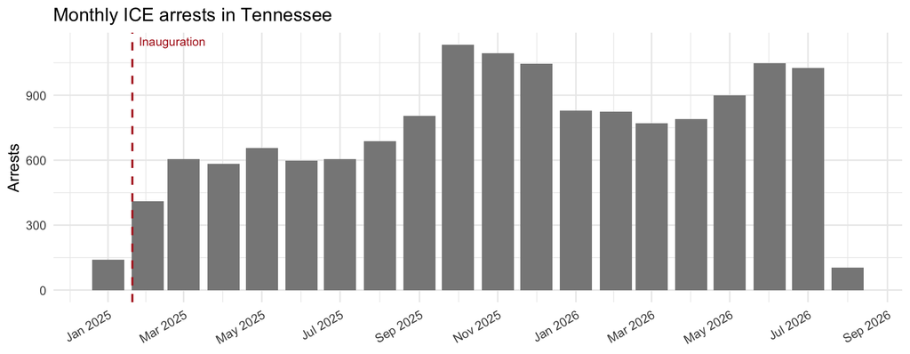

### Who was arrested

**Top nationalities**

| Country | N | % |
| --- | --- | --- |
| MEXICO | 5148 | 35.1 |
| GUATEMALA | 3780 | 25.8 |
| HONDURAS | 2395 | 16.3 |
| VENEZUELA | 1073 | 7.3 |
| NICARAGUA | 397 | 2.7 |
| EL SALVADOR | 359 | 2.4 |
| COLOMBIA | 289 | 2.0 |
| CUBA | 156 | 1.1 |
| EGYPT | 91 | 0.6 |
| INDIA | 77 | 0.5 |
| JAMAICA | 77 | 0.5 |
| CHINA, PEOPLES REPUBLIC OF | 72 | 0.5 |
| PERU | 59 | 0.4 |
| ECUADOR | 57 | 0.4 |
| VIETNAM | 55 | 0.4 |

**Arrest type**

| Arrest type | N | % |
| --- | --- | --- |
| Custodial Arrest | 8875 | 60.6 |
| At-Large Arrest | 4499 | 30.7 |
| 287(g) Program | 1270 | 8.7 |
| Other | 12 | 0.1 |

**Criminality at arrest**

| Criminality | N | % |
| --- | --- | --- |
| 2 Pending Criminal Charges | 5938 | 40.5 |
| 1 Convicted Criminal | 5116 | 34.9 |
| 3 Other Immigration Violator | 3602 | 24.6 |

## Arrest Locations in Tennessee

County-level map. When the release carries an apprehension city (Aug 2026 release) and a Census place-county crosswalk exists for the state, counties are attributed from the **arrest city** first and from `apprehension_site_landmark` second (validated against each state’s county list); records with non-specific landmarks (e.g. “SPM General Area”) use state-specific office rules where possible; others are excluded.

[interactive chart not shown]

> **Coverage:** 96% of arrests mapped to a county.

> **Caveat:** for at-large arrests the apprehension city can record the ICE processing point rather than the arrest location. Validation against the landmark field shows most city values are genuine arrest municipalities, but a few sites are dominated by processing locations — Broadview, IL (an ICE processing center; 63% of its rows are at-large) and Fort Snelling, MN (the MSP airport CDP, the top reported city for St. Paul general-area rows). Counties dominated by such sites should be read with that ambiguity in mind.

```
**County attribution:** City 83% · Landmark 13.3% · Unmapped 3.7%

**Unmapped arrests** ( 548  of  14656 ): City not found in state 99.1% · Fugitive operations, no county 0.4% · No city or landmark 0.4% · Other / unresolved 0.2%



Table: Largest unmapped arrest locations

|Reason                         |Landmark                                      |Type                     |   N|
|:------------------------------|:---------------------------------------------|:------------------------|---:|
|City not found in state        |FUGITIVE OPERATIONS TN STATE                  |Fugitive ops (no county) | 248|
|City not found in state        |TN DEPT. OF CORRECTIONS - TURNEY CENTER       |Other                    |   8|
|City not found in state        |CAP - FAYETTEE COUNTY JAIL TN STATE           |County jail / sheriff    |   6|
|City not found in state        |Trousdale Turner Correctional Facility        |State prison             |   4|
|City not found in state        |TN DEPT. OF CORRECTIONS - LOS DEBERRY SPECIAL |Other                    |   3|
|City not found in state        |MEMPHIS ERO OFFICE                            |ICE office               |   2|
|City not found in state        |OLD                                           |Other                    |   2|
|Fugitive operations, no county |FUGITIVE OPERATIONS TN STATE                  |Fugitive ops (no county) |   2|
|City not found in state        |DALLAS COUNTY GENERAL AREA                    |County jail / sheriff    |   1|
|City not found in state        |DUTY WINDOW 126 NORTHPOINT                    |Other                    |   1|
|City not found in state        |FUGITIVE OPERATIONS  MS STATE                 |Fugitive ops (no county) |   1|
|City not found in state        |RINGGOLD, GA                                  |Other                    |   1|
|City not found in state        |RIVERBEND MAX TDOC                            |Other                    |   1|
|City not found in state        |TN HIGHWAY PATROL                             |Other                    |   1|
|Other / unresolved             |MEMPHIS ERO OFFICE                            |ICE office               |   1|
```

## Detention Facility Maps and Transfer Flows

**Blue dots** = first detention facility. **Orange dots** = last detention facility. **Grey lines** = transfer flows between facilities; line width is proportional to the log of the number of transfers on that route. Only flows with ≥ 14 transfers are shown.

[interactive chart not shown]

**First detention facility (top 8):**

| DETLOC | Facility | City | State | N | % |
| --- | --- | --- | --- | --- | --- |
| NSVHOLD | Nashville Hold Room | Nashville | TN | 3611 | 24.4 |
| MEMHOLD | Memphis Hold Room | Memphis | TN | 2970 | 20.1 |
| KNXHOLD | Knoxville Hold Room | Knoxville | TN | 2722 | 18.4 |
| CNGHOLD | Chattanooga Hold Room | Chattanooga | TN | 2160 | 14.6 |
| PUTNMTN | Putnam County Sheriff | Cookeville | TN | 1251 | 8.4 |
| KNXDFTN | Knox County Detention Facility | Knoxville | TN | 1112 | 7.5 |
| ETOWAAL | Etowah County Jail | Gadsden | AL | 336 | 2.3 |
| FSF | Florence Staging Facility | Florence | AZ | 69 | 0.5 |

**Last detention facility (top 10):**

| DETLOC | Facility | City | State | N | % |
| --- | --- | --- | --- | --- | --- |
| LAWINCI | Winn Correctional Center | Winnfield | LA | 2756 | 18.6 |
| JENATLA | Alexandria Staging Facility | Alexandria | LA | 1989 | 13.4 |
| JENADLA | Central Louisiana ICE Processing Center (CLIPC) | Jena | LA | 1438 | 9.7 |
| JKPCCLA | Jackson Parish Correctional Center | Jonesboro | LA | 1257 | 8.5 |
| PINEPLA | Pine Prairie ICE Processing Center | Pine Prairie | LA | 1142 | 7.7 |
| ADAMSMS | Adams County Detention Center (Mississippi) | Natchez | MS | 960 | 6.5 |
| BASILLA | South Louisiana ICE Processing Center | Basile | LA | 832 | 5.6 |
| RWCCMLA | Richwood Correctional Center | Monroe | LA | 790 | 5.3 |
| PIC | Port Isabel Detention Center | Los Fresnos | TX | 659 | 4.5 |
| TNWESDF | Western Tennessee Detention Facility | Mason | TN | 518 | 3.5 |

## Removal Pipeline Flow

Each band traces one group through the pipeline: **Tennessee arrest → first facility → last facility → outcome.** Band width is proportional to number of stays.

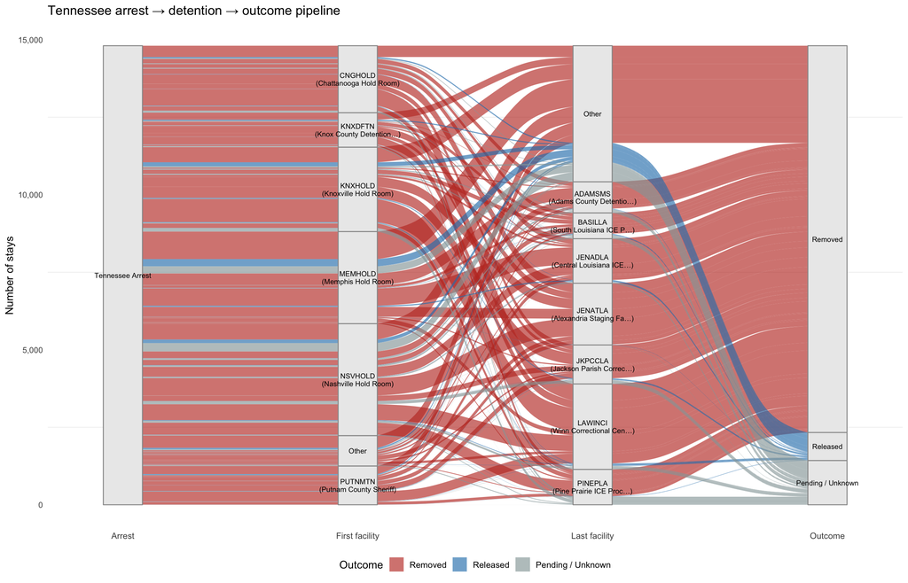

**Final outcomes:**

| Release reason | N | % |
| --- | --- | --- |
| Removed | 12474 | 84.2 |
| NA | 1428 | 9.6 |
| Bonded Out - IJ | 222 | 1.5 |
| U.S. Marshals or other agency (explain in Detention Comments) | 148 | 1.0 |
| Voluntary departure | 136 | 0.9 |
| Transferred | 123 | 0.8 |
| Court Ordered | 96 | 0.6 |
| Order of recognizance | 44 | 0.3 |
| Relief Granted by IJ | 34 | 0.2 |
| Order of supervision | 26 | 0.2 |
| Proceedings Terminated | 23 | 0.2 |
| Order of Recognizance - Humanitarian | 14 | 0.1 |
| Paroled | 8 | 0.1 |
| Bonded Out - Field Office | 5 | 0.0 |
| Order of Supervision - Humanitarian | 5 | 0.0 |
| ORR - Office of Refugee Resettlement | 4 | 0.0 |
| Paroled - Humanitarian | 4 | 0.0 |
| ORR-Runaway | 3 | 0.0 |
| Order of Supervision - Re-Release | 3 | 0.0 |
| Died | 2 | 0.0 |
| Escaped | 1 | 0.0 |
| Order of Supervision - No SLRRFF | 1 | 0.0 |
| Paroled - Fear Found | 1 | 0.0 |
| Withdrawal | 1 | 0.0 |

**All facilities in itineraries (top 15):**

| DETLOC | Appearances | % of stays |
| --- | --- | --- |
| KNXDFTN | 4747 | 32.1 |
| ETOWAAL | 4554 | 30.8 |
| NSVHOLD | 3923 | 26.5 |
| TNWESDF | 3782 | 25.5 |
| LAWINCI | 3775 | 25.5 |
| MEMHOLD | 3022 | 20.4 |
| KNXHOLD | 2863 | 19.3 |
| JENATLA | 2734 | 18.5 |
| PUTNMTN | 2679 | 18.1 |
| JENADLA | 2431 | 16.4 |
| CNGHOLD | 2167 | 14.6 |
| JKPCCLA | 1912 | 12.9 |
| PINEPLA | 1668 | 11.3 |
| PCKNSAL | 1424 | 9.6 |
| ADAMSMS | 1370 | 9.3 |

## Removal Destinations

The heatmap below crosses **citizenship country** (columns) against **country deported to** (rows). Cell numbers are absolute counts; cell color shows what share of that row’s removals came from each citizenship group. Top 15 destinations × top 12 citizenships shown.

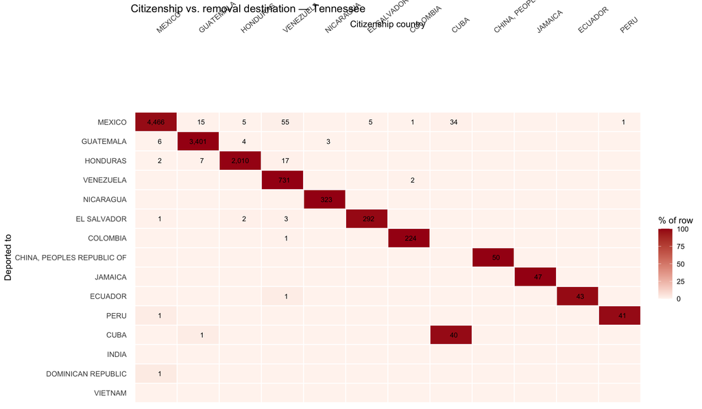

**Summary table:**

Removal destinations for Tennessee arrests

| Country | N | % |
| --- | --- | --- |
| MEXICO | 4582 | 37.5 |
| GUATEMALA | 3414 | 28.0 |
| HONDURAS | 2037 | 16.7 |
| VENEZUELA | 733 | 6.0 |
| NICARAGUA | 323 | 2.6 |
| EL SALVADOR | 298 | 2.4 |
| COLOMBIA | 225 | 1.8 |
| CHINA, PEOPLES REPUBLIC OF | 50 | 0.4 |
| JAMAICA | 47 | 0.4 |
| ECUADOR | 44 | 0.4 |
| PERU | 42 | 0.3 |
| CUBA | 41 | 0.3 |
| INDIA | 38 | 0.3 |
| DOMINICAN REPUBLIC | 29 | 0.2 |
| VIETNAM | 26 | 0.2 |
| EGYPT | 25 | 0.2 |
| ROMANIA | 25 | 0.2 |
| HAITI | 21 | 0.2 |
| LAOS | 21 | 0.2 |
| SENEGAL | 17 | 0.1 |

## Minor Detainees (Under 18)

**120 arrests** · **119 distinct individuals** · **106 detention stays.** Age is estimated as year(arrest) − birth year and may be off by up to one year.

| Metric | Value |
| --- | --- |
| Arrests of minors | 120 |
| Distinct minors | 119 |
| Detention stays | 106 |

**Age at arrest**

| Age | N |
| --- | --- |
| 3 | 2 |
| 4 | 6 |
| 5 | 5 |
| 6 | 7 |
| 7 | 9 |
| 8 | 6 |
| 9 | 8 |
| 10 | 5 |
| 11 | 7 |
| 12 | 8 |
| 13 | 9 |
| 14 | 8 |
| 15 | 5 |
| 16 | 15 |
| 17 | 20 |

**Nationality**

| Country | N | % |
| --- | --- | --- |
| GUATEMALA | 38 | 31.7 |
| HONDURAS | 35 | 29.2 |
| MEXICO | 23 | 19.2 |
| VENEZUELA | 6 | 5.0 |
| COLOMBIA | 5 | 4.2 |
| NICARAGUA | 4 | 3.3 |
| EGYPT | 3 | 2.5 |
| AFGHANISTAN | 2 | 1.7 |
| EL SALVADOR | 2 | 1.7 |
| BRAZIL | 1 | 0.8 |
| ECUADOR | 1 | 0.8 |

**First detention facility**

| DETLOC | Facility | N | % |
| --- | --- | --- | --- |
| MEMHOLD | MEMPHIS HOLD ROOM | 68 | 64.2 |
| NSVHOLD | NASHVILLE HOLD ROOM | 18 | 17.0 |
| KNXHOLD | KNOXVILLE HOLD ROOM | 12 | 11.3 |
| BOPCNV | NASHVILLE COMM. CORR. | 7 | 6.6 |
| PHOHOLD | PHOENIX DIST OFFICE | 1 | 0.9 |

**Last detention facility**

| DETLOC | Facility | N | % |
| --- | --- | --- | --- |
| MEMHOLD | MEMPHIS HOLD ROOM | 53 | 50.0 |
| NSVHOLD | NASHVILLE HOLD ROOM | 18 | 17.0 |
| STFRCTX | SOUTH TEXAS FAM RESIDENTIAL CENTER | 14 | 13.2 |
| KNXHOLD | KNOXVILLE HOLD ROOM | 12 | 11.3 |
| BOPCNV | NASHVILLE COMM. CORR. | 7 | 6.6 |
| ABRXSPA | ABRAXAS ACADEMY | 1 | 0.9 |
| PHOHOLD | PHOENIX DIST OFFICE | 1 | 0.9 |

**Outcomes**

| Release reason | N | % |
| --- | --- | --- |
| Removed | 69 | 65.1 |
| Voluntary departure | 15 | 14.2 |
| Order of recognizance | 6 | 5.7 |
| ORR - Office of Refugee Resettlement | 3 | 2.8 |
| ORR-Runaway | 3 | 2.8 |
| Paroled | 3 | 2.8 |
| Order of supervision | 2 | 1.9 |
| NA | 2 | 1.9 |
| Escaped | 1 | 0.9 |
| Order of Recognizance - Humanitarian | 1 | 0.9 |
| Proceedings Terminated | 1 | 0.9 |